# Personal Humidex and heart rate: within-participant analysis

Author

Alessandro Fuschi

## Setup

```r
library(tidyverse)

cfg <- list(
  data_dir = file.path("data", "5min"), timezone = "UTC", analysis_start_date = as.Date("2025-03-01"),
  max_steps = 10, sensitivity_max_steps = 20, bucket_minutes = 5, recent_minutes = 15,
  reference_humidex = 25, hot_humidex = 40, support_half_width = 2, minimum_support_buckets = 6,
  humidex_knots = c(20, 30, 40), humidex_boundary = c(10, 50), plot_range = c(20, 45),
  minimum_plot_participants = 10, confidence_level = 0.95,
  alternative_humidity = 60, temperature_support_width = 2, humidity_support_width = 10,
  temperature_knots = c(20, 30), temperature_boundary = c(5, 45),
  humidity_knots = c(40, 70), humidity_boundary = c(0, 100)
)

theme_set(theme_minimal(base_size = 12))
```

## Analysis question and decisions

During low recorded activity, is higher personal Humidex associated with higher heart rate **within the same participant**? The primary estimate is the adjusted heart-rate difference at Humidex 40 versus 25, in bpm. Breathing rate is secondary, not independent physiological confirmation unless its measurement method is verified.

These decisions were recorded on 2026-09-04, **after exploratory plots had been examined**. This is an exploratory inferential analysis, not a preregistered confirmatory test. Model specifications below are not selected by significance. The descriptive notebook remains separate.

[output not shown]

## Local data and analytical selection

Upstream ETL tables are used as supplied. Humidex uses MyAir temperature (°C) and relative humidity (%), assuming MyAir accompanied the participant. Observed-minute coverage is retained but not used as a precision weight.

```r
if (!exists("myair_5min", inherits = FALSE)) {
  myair_5min <- read_csv(
    file.path(cfg$data_dir, "myair_5min.csv.gz"),
    col_types = cols(userId = col_character(), bucket_5min = col_datetime(), deviceId = col_character(), firmware = col_character()),
    locale = locale(tz = cfg$timezone), na = c("", "NA", "NULL"), show_col_types = FALSE
  )
}
if (!exists("smartwatchhigh_5min", inherits = FALSE)) {
  smartwatchhigh_5min <- read_csv(
    file.path(cfg$data_dir, "smartwatchhigh_5min.csv.gz"),
    col_types = cols(userId = col_character(), bucket_5min = col_datetime(), deviceId = col_character(), firmware = col_character()),
    locale = locale(tz = cfg$timezone), na = c("", "NA", "NULL"), show_col_types = FALSE
  )
}
if (!exists("smartwatchlow_5min", inherits = FALSE)) {
  smartwatchlow_5min <- read_csv(
    file.path(cfg$data_dir, "smartwatchlow_5min.csv.gz"),
    col_types = cols(userId = col_character(), bucket_5min = col_datetime(), deviceId = col_character(), firmware = col_character()),
    locale = locale(tz = cfg$timezone), na = c("", "NA", "NULL"), show_col_types = FALSE
  )
}

exposure <- myair_5min %>%
  select(userId, bucket_5min, air_minutes = observed_minute_n, temperature = temperature_mean, humidity = humidity_mean) %>%
  filter(as.Date(bucket_5min, tz = cfg$timezone) > cfg$analysis_start_date,
         as.Date(bucket_5min, tz = cfg$timezone) < Sys.Date()) %>%
  left_join(
    smartwatchhigh_5min %>% select(userId, bucket_5min, watch_minutes = observed_minute_n,
                                  heartrate = heartrate_mean, breathrate = breathrate_mean),
    by = c("userId", "bucket_5min"), relationship = "one-to-one"
  ) %>%
  left_join(smartwatchlow_5min %>% select(userId, bucket_5min, steps = step_mean),
            by = c("userId", "bucket_5min"), relationship = "one-to-one") %>%
  mutate(humidex = ThermIndex::humidex(temperature, humidity),
         period = format(bucket_5min, "%Y-%m", tz = cfg$timezone),
         hour = lubridate::hour(bucket_5min) + lubridate::minute(bucket_5min) / 60)

paired <- exposure %>% filter(is.finite(humidex), is.finite(steps), steps >= 0, is.finite(heartrate))
low_activity <- paired %>% filter(steps <= cfg$max_steps)
participant_support <- low_activity %>%
  group_by(userId) %>%
  summarise(reference_buckets = sum(abs(humidex - cfg$reference_humidex) <= cfg$support_half_width),
            hot_buckets = sum(abs(humidex - cfg$hot_humidex) <= cfg$support_half_width), .groups = "drop")
eligible <- participant_support %>%
  filter(reference_buckets >= cfg$minimum_support_buckets, hot_buckets >= cfg$minimum_support_buckets)
primary_data <- low_activity %>% semi_join(eligible, by = "userId")

selection <- tibble(
  selection = c("MyAir: study window", "Paired Humidex, nonnegative steps and heart rate", "Low activity", "Supported primary cohort"),
  buckets = c(nrow(exposure), nrow(paired), nrow(low_activity), nrow(primary_data)),
  participants = c(n_distinct(exposure$userId), n_distinct(paired$userId), n_distinct(low_activity$userId), n_distinct(primary_data$userId))
) %>% mutate(buckets_removed = lag(buckets) - buckets)
selection %>% knitr::kable(big.mark = ",", caption = "Analytical selection: observed five-minute buckets")
```

Analytical selection: observed five-minute buckets

| selection | buckets | participants | buckets_removed |
| --- | --- | --- | --- |
| MyAir: study window | 1352278 | 187 | NA |
| Paired Humidex, nonnegative steps and heart rate | 876988 | 165 | 475290 |
| Low activity | 574521 | 165 | 302467 |
| Supported primary cohort | 426037 | 63 | 148484 |

## Exposure support

The support rule concerns observed exposure, not covariate overlap after adjustment. The second table shows how often both exposure regions also occur within the same participant and month. Sparse overlap makes adjustment more model-dependent.

```r
support_grid <- tibble(humidex = seq(cfg$plot_range[1], cfg$plot_range[2], by = 0.5))
support_grid$participants <- 0L
for (i in seq_len(nrow(support_grid))) {
  nearby <- primary_data %>% filter(abs(humidex - support_grid$humidex[i]) <= cfg$support_half_width)
  support_grid$participants[i] <- n_distinct(nearby$userId)
}

primary_data %>%
  mutate(thermal_band = cut(humidex, c(-Inf, 20, 30, 40, Inf), right = FALSE)) %>%
  group_by(thermal_band) %>%
  summarise(buckets = n(), participants = n_distinct(userId),
            median_air_minutes = median(air_minutes, na.rm = TRUE),
            median_watch_minutes = median(watch_minutes, na.rm = TRUE), .groups = "drop") %>%
  knitr::kable(big.mark = ",", caption = "Primary cohort coverage; observed minutes per five-minute bucket")
```

Primary cohort coverage; observed minutes per five-minute bucket

| thermal_band | buckets | participants | median_air_minutes | median_watch_minutes |
| --- | --- | --- | --- | --- |
| [-Inf,20) | 12425 | 36 | 5 | 5 |
| [20,30) | 259436 | 63 | 5 | 5 |
| [30,40) | 148248 | 63 | 5 | 5 |
| [40, Inf) | 5928 | 55 | 5 | 5 |

```r
period_support <- primary_data %>%
  group_by(userId, period) %>%
  summarise(reference_buckets = sum(abs(humidex - cfg$reference_humidex) <= cfg$support_half_width),
            hot_buckets = sum(abs(humidex - cfg$hot_humidex) <= cfg$support_half_width), .groups = "drop") %>%
  mutate(both = reference_buckets >= cfg$minimum_support_buckets & hot_buckets >= cfg$minimum_support_buckets)
period_support %>%
  summarise(participant_months = n(), supported_participant_months = sum(both),
            participants_with_supported_month = n_distinct(userId[both])) %>%
  knitr::kable(caption = "Within-month exposure overlap in the primary cohort")
```

Within-month exposure overlap in the primary cohort

| participant_months | supported_participant_months | participants_with_supported_month |
| --- | --- | --- |
| 324 | 76 | 43 |

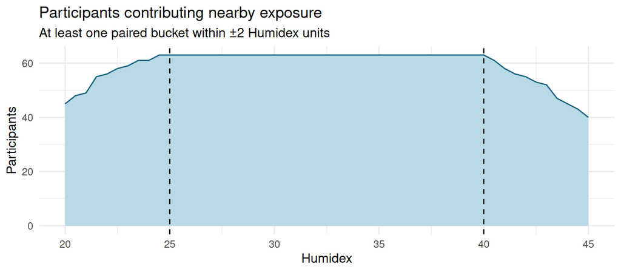

```r
support_grid %>% ggplot(aes(humidex, participants)) +
  geom_area(fill = "#b8d9e6") + geom_line(color = "#17617d") +
  geom_vline(xintercept = c(cfg$reference_humidex, cfg$hot_humidex), linetype = "dashed") +
  labs(title = "Participants contributing nearby exposure", x = "Humidex",
       y = "Participants", subtitle = "At least one paired bucket within ±2 Humidex units")
```

## Robustness specifications

All sensitivity analyses begin with the primary eligible cohort. They change one rule at a time; their own bucket and participant counts are reported. Zero-step selection omits the constant steps covariate. The 15-minute history is built from **exactly adjacent** five-minute timestamps, never across gaps. A complete-history analysis separates loss of coverage from the effect of requiring recent low activity.

Participant-by-month intercepts provide a stricter within-person, within-month comparison; equal-bucket weighting checks sensitivity to monitoring duration. Secondary breathing-rate analysis uses available records in the primary cohort. These estimates are not additional confirmatory tests.

```r
analysis_pool <- paired %>% semi_join(eligible, by = "userId")
recent_steps <- smartwatchlow_5min %>%
  select(userId, bucket_5min, steps = step_mean) %>%
  filter(as.Date(bucket_5min, tz = cfg$timezone) > cfg$analysis_start_date,
         as.Date(bucket_5min, tz = cfg$timezone) < Sys.Date())
history_columns <- paste0("steps_lag_", seq_len(cfg$recent_minutes / cfg$bucket_minutes))
for (i in seq_along(history_columns)) {
  previous <- recent_steps %>% mutate(bucket_5min = bucket_5min + i * cfg$bucket_minutes * 60)
  names(previous)[names(previous) == "steps"] <- history_columns[i]
  analysis_pool <- analysis_pool %>% left_join(previous, by = c("userId", "bucket_5min"), relationship = "one-to-one")
}
analysis_pool <- analysis_pool %>%
  mutate(complete_history = if_all(all_of(history_columns), ~ is.finite(.x) & .x >= 0),
         recent_low = if_all(all_of(history_columns), ~ is.finite(.x) & between(.x, 0, cfg$max_steps)))

specifications <- tibble(
  analysis = c("Primary", "Zero steps", "Steps ≤20", "Complete 15-min history", "Low activity in preceding 15 min",
               "Participant × month intercepts", "Equal bucket weights", "Breathing rate (secondary)"),
  max_steps = c(cfg$max_steps, 0, cfg$sensitivity_max_steps, rep(cfg$max_steps, 5)),
  history = c("none", "none", "none", "complete", "low", "none", "none", "none"),
  participant_month = c(rep(FALSE, 5), TRUE, FALSE, FALSE),
  equal_participant_weight = c(rep(TRUE, 6), FALSE, TRUE),
  outcome = c(rep("heartrate", 7), "breathrate")
)
```

## Adjusted models

The model is `outcome = participant intercept + f(Humidex) + year-month + cyclic hour + steps`. Fixed intercepts are absorbed by centering the outcome **and every design column** within participant (or participant-month in that sensitivity). This is algebraically equivalent to weighted least squares with explicit fixed-effect indicators, without allocating a large indicator matrix.

Cluster covariance follows [Cameron and Miller](https://cameron.econ.ucdavis.edu/research/Cameron_Miller_JHR_2015.pdf): participant score sums, CR1 factor `G/(G−1) × (N−1)/(N−K)`, with absorbed intercepts included in K. This accounts for within-person serial correlation, not time-varying confounding or shared errors between different participants. No normality assumption is made for the raw heart-rate distribution.

```r
model_results <- list()
model_objects <- list()

for (s in seq_len(nrow(specifications))) {
  specification <- specifications[s, ]
  model_data <- analysis_pool %>%
    filter(steps <= specification$max_steps, is.finite(.data[[specification$outcome]]))
  if (specification$history == "complete") model_data <- model_data %>% filter(complete_history)
  if (specification$history == "low") model_data <- model_data %>% filter(recent_low)
  model_data <- model_data %>%
    mutate(fixed_group = if (specification$participant_month) paste(userId, period) else userId) %>%
    group_by(fixed_group) %>% filter(n() > 1) %>% ungroup() %>%
    group_by(userId) %>% mutate(weight = if (specification$equal_participant_weight) 1 / n() else 1) %>% ungroup()

  heat_basis <- splines::ns(model_data$humidex, knots = cfg$humidex_knots, Boundary.knots = cfg$humidex_boundary)
  colnames(heat_basis) <- paste0("heat", seq_len(ncol(heat_basis)))
  controls <- cbind(hour_sin = sin(2 * pi * model_data$hour / 24), hour_cos = cos(2 * pi * model_data$hour / 24),
                    hour_sin2 = sin(4 * pi * model_data$hour / 24), hour_cos2 = cos(4 * pi * model_data$hour / 24))
  if (specification$max_steps > 0) controls <- cbind(controls, steps = model_data$steps)
  if (!specification$participant_month && n_distinct(model_data$period) > 1) {
    controls <- cbind(controls, model.matrix(~ factor(period), model_data)[, -1, drop = FALSE])
  }
  design <- cbind(heat_basis, controls)
  group_index <- match(model_data$fixed_group, unique(model_data$fixed_group))
  group_weight <- as.numeric(rowsum(model_data$weight, group_index, reorder = FALSE))
  design_means <- rowsum(design * model_data$weight, group_index, reorder = FALSE) / group_weight
  outcome_means <- as.numeric(rowsum(model_data[[specification$outcome]] * model_data$weight,
                                    group_index, reorder = FALSE)) / group_weight
  within_design <- design - design_means[group_index, , drop = FALSE]
  within_outcome <- model_data[[specification$outcome]] - outcome_means[group_index]
  weighted_design <- within_design * sqrt(model_data$weight)
  design_qr <- qr(weighted_design)
  retained_columns <- sort(design_qr$pivot[seq_len(design_qr$rank)])
  within_design <- within_design[, retained_columns, drop = FALSE]
  weighted_design <- weighted_design[, retained_columns, drop = FALSE]
  fit <- lm.fit(weighted_design, within_outcome * sqrt(model_data$weight))
  bread <- solve(crossprod(weighted_design))
  residual <- within_outcome - as.numeric(within_design %*% fit$coefficients)
  cluster_index <- match(model_data$userId, unique(model_data$userId))
  cluster_scores <- rowsum(within_design * (model_data$weight * residual), cluster_index, reorder = FALSE)
  clusters <- n_distinct(model_data$userId)
  parameters <- ncol(within_design) + length(group_weight)
  correction <- clusters / (clusters - 1) * (nrow(model_data) - 1) / (nrow(model_data) - parameters)
  covariance <- correction * bread %*% crossprod(cluster_scores) %*% bread

  contrast_basis <- predict(heat_basis, c(cfg$reference_humidex, cfg$hot_humidex))
  contrast <- setNames(rep(0, ncol(design)), colnames(design))
  contrast[colnames(heat_basis)] <- contrast_basis[2, ] - contrast_basis[1, ]
  contrast <- contrast[retained_columns]
  estimate <- sum(contrast * fit$coefficients)
  standard_error <- sqrt(as.numeric(t(contrast) %*% covariance %*% contrast))
  critical <- qt((1 + cfg$confidence_level) / 2, df = clusters - 1)
  own_support <- model_data %>% group_by(userId) %>%
    summarise(reference = sum(abs(humidex - cfg$reference_humidex) <= cfg$support_half_width),
              hot = sum(abs(humidex - cfg$hot_humidex) <= cfg$support_half_width), .groups = "drop")
  model_results[[s]] <- tibble(
    analysis = specification$analysis, outcome = specification$outcome, buckets = nrow(model_data), participants = clusters,
    supported_participants = sum(own_support$reference >= cfg$minimum_support_buckets & own_support$hot >= cfg$minimum_support_buckets),
    estimate = estimate, lower = estimate - critical * standard_error, upper = estimate + critical * standard_error,
    omitted_columns = ncol(design) - length(retained_columns)
  )
  if (s == 1) {
    model_objects$primary <- list(coefficients = fit$coefficients, covariance = covariance, critical = critical,
      heat_basis = heat_basis, contrast = contrast, design = within_design, outcome = within_outcome,
      weights = model_data$weight, cluster_index = cluster_index, data = model_data, bread = bread)
  }
}
results <- bind_rows(model_results)
results %>%
  mutate(unit = if_else(outcome == "heartrate", "bpm", "breaths/min")) %>%
  select(analysis, unit, buckets, participants, supported_participants, estimate, lower, upper, omitted_columns) %>%
  knitr::kable(digits = 2, big.mark = ",", caption = "Adjusted Humidex 40 versus 25 differences and 95% participant-clustered intervals")
```

Adjusted Humidex 40 versus 25 differences and 95% participant-clustered intervals

| analysis | unit | buckets | participants | supported_participants | estimate | lower | upper | omitted_columns |
| --- | --- | --- | --- | --- | --- | --- | --- | --- |
| Primary | bpm | 426037 | 63 | 63 | 2.93 | 0.93 | 4.93 | 0 |
| Zero steps | bpm | 425313 | 63 | 63 | 2.95 | 0.94 | 4.96 | 0 |
| Steps ≤20 | bpm | 463550 | 63 | 63 | 2.77 | 0.84 | 4.70 | 0 |
| Complete 15-min history | bpm | 424075 | 63 | 63 | 2.89 | 0.90 | 4.89 | 0 |
| Low activity in preceding 15 min | bpm | 281282 | 63 | 51 | 3.80 | 1.28 | 6.33 | 0 |
| Participant × month intercepts | bpm | 426032 | 63 | 63 | 3.20 | 0.86 | 5.53 | 0 |
| Equal bucket weights | bpm | 426037 | 63 | 63 | 2.95 | 1.34 | 4.55 | 0 |
| Breathing rate (secondary) | breaths/min | 352257 | 42 | 42 | 0.94 | -0.10 | 1.98 | 0 |

`supported_participants` reapplies the six-bucket rule to each model’s retained observations; sensitivity cohorts are not reselected on this measure. Lost support increases model dependence. `omitted_columns` reports any non-estimable design columns after fixed-effect absorption.

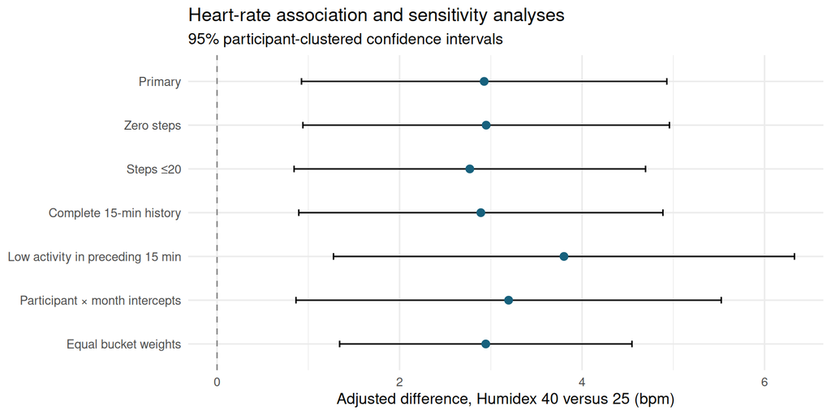

```r
results %>% filter(outcome == "heartrate") %>%
  mutate(analysis = factor(analysis, levels = rev(specifications$analysis))) %>%
  ggplot(aes(estimate, analysis, xmin = lower, xmax = upper)) +
  geom_vline(xintercept = 0, linetype = "dashed", color = "grey55") +
  geom_errorbar(orientation = "y", width = 0.15) + geom_point(size = 2.5, color = "#17617d") +
  labs(title = "Heart-rate association and sensitivity analyses", y = NULL,
       x = "Adjusted difference, Humidex 40 versus 25 (bpm)", subtitle = "95% participant-clustered confidence intervals")
```

## Adjusted exposure-response curve

The curve is the primary model’s difference relative to Humidex 25, holding adjustment variables fixed. A shared exposure-response shape is assumed. The reference is zero by construction, so its interval has zero width.

```r
primary <- model_objects$primary
curve_data <- support_grid %>% filter(participants >= cfg$minimum_plot_participants)
curve_design <- matrix(0, nrow(curve_data), length(primary$coefficients), dimnames = list(NULL, names(primary$coefficients)))
curve_basis <- predict(primary$heat_basis, curve_data$humidex)
reference_basis <- as.numeric(predict(primary$heat_basis, cfg$reference_humidex))
curve_design[, colnames(primary$heat_basis)] <- sweep(curve_basis, 2, reference_basis)
curve_data <- curve_data %>%
  mutate(estimate = as.numeric(curve_design %*% primary$coefficients),
         standard_error = sqrt(pmax(0, rowSums((curve_design %*% primary$covariance) * curve_design))),
         lower = estimate - primary$critical * standard_error, upper = estimate + primary$critical * standard_error)
```

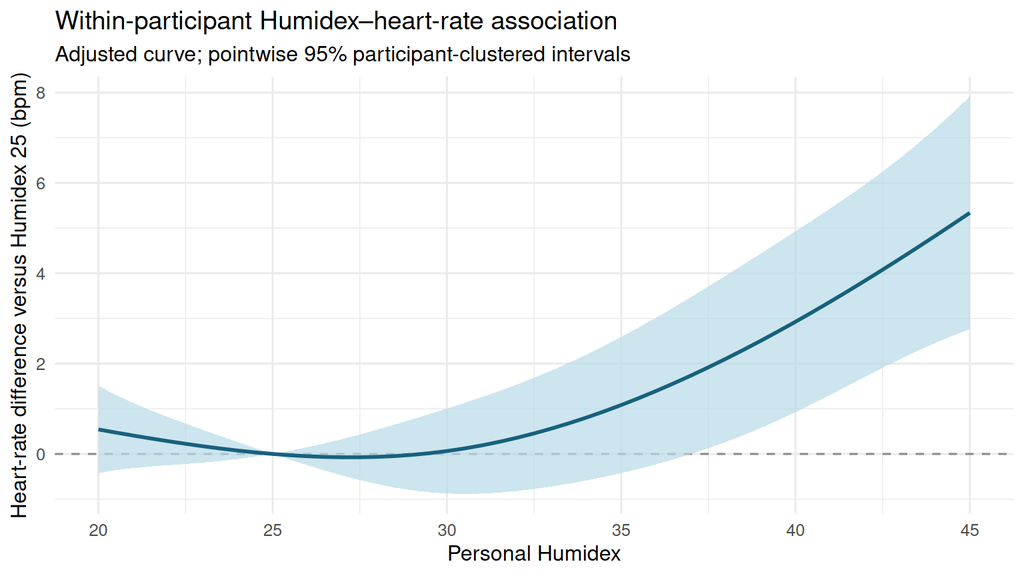

```r
curve_data %>% ggplot(aes(humidex, estimate)) +
  geom_hline(yintercept = 0, linetype = "dashed", color = "grey55") +
  geom_ribbon(aes(ymin = lower, ymax = upper), fill = "#b8d9e6", alpha = 0.7) +
  geom_line(color = "#17617d", linewidth = 1) +
  labs(title = "Within-participant Humidex–heart-rate association", x = "Personal Humidex",
       y = "Heart-rate difference versus Humidex 25 (bpm)", subtitle = "Adjusted curve; pointwise 95% participant-clustered intervals")
```

## Alternative exposure specification

As a sensitivity to the composite index, temperature and relative humidity replace Humidex with **separate additive natural splines**. Temperature knots are 20/30 °C (boundaries 5/45 °C); humidity knots are 40/70% (boundaries 0/100%). Adjustment, participants and weights are unchanged. No temperature–humidity interaction is fitted in this alternative.

For illustration, temperatures corresponding to Humidex 25 and 40 are calculated at a fixed 60% RH, a specified mid-range scenario rather than an exposure average. This estimates a temperature contrast at constant humidity, **not the same estimand** as the main Humidex contrast. Nearby coverage uses ±2 °C and ±10 percentage points RH, with at least six buckets at each end.

```r
alternative_conditions <- tibble(humidex = c(cfg$reference_humidex, cfg$hot_humidex), humidity = cfg$alternative_humidity,
                                temperature = NA_real_)
for (i in seq_len(nrow(alternative_conditions))) {
  alternative_conditions$temperature[i] <- uniroot(
    function(temperature) ThermIndex::humidex(temperature, cfg$alternative_humidity) - alternative_conditions$humidex[i],
    interval = cfg$temperature_boundary
  )$root
}
alternative_support <- primary$data %>% group_by(userId) %>%
  summarise(reference = sum(abs(temperature - alternative_conditions$temperature[1]) <= cfg$temperature_support_width &
                              abs(humidity - cfg$alternative_humidity) <= cfg$humidity_support_width),
            hot = sum(abs(temperature - alternative_conditions$temperature[2]) <= cfg$temperature_support_width &
                        abs(humidity - cfg$alternative_humidity) <= cfg$humidity_support_width), .groups = "drop")
temperature_basis <- splines::ns(primary$data$temperature, knots = cfg$temperature_knots, Boundary.knots = cfg$temperature_boundary)
humidity_basis <- splines::ns(primary$data$humidity, knots = cfg$humidity_knots, Boundary.knots = cfg$humidity_boundary)
alternative_basis <- cbind(temperature_basis, humidity_basis)
colnames(alternative_basis) <- c(paste0("temperature", seq_len(ncol(temperature_basis))), paste0("humidity", seq_len(ncol(humidity_basis))))
alternative_group_weight <- as.numeric(rowsum(primary$weights, primary$cluster_index, reorder = FALSE))
alternative_means <- rowsum(alternative_basis * primary$weights, primary$cluster_index, reorder = FALSE) / alternative_group_weight
alternative_design <- cbind(alternative_basis - alternative_means[primary$cluster_index, , drop = FALSE],
                            primary$design[, !startsWith(colnames(primary$design), "heat"), drop = FALSE])
alternative_fit <- lm.fit(alternative_design * sqrt(primary$weights), primary$outcome * sqrt(primary$weights))
alternative_bread <- solve(crossprod(alternative_design, alternative_design * primary$weights))
alternative_residual <- primary$outcome - as.numeric(alternative_design %*% alternative_fit$coefficients)
alternative_scores <- rowsum(alternative_design * (primary$weights * alternative_residual), primary$cluster_index, reorder = FALSE)
alternative_clusters <- results$participants[1]
alternative_parameters <- ncol(alternative_design) + alternative_clusters
alternative_correction <- alternative_clusters / (alternative_clusters - 1) *
  (nrow(alternative_design) - 1) / (nrow(alternative_design) - alternative_parameters)
alternative_covariance <- alternative_correction * alternative_bread %*% crossprod(alternative_scores) %*% alternative_bread
temperature_contrast_basis <- predict(temperature_basis, alternative_conditions$temperature)
alternative_contrast <- c(temperature_contrast_basis[2, ] - temperature_contrast_basis[1, ],
                          rep(0, ncol(alternative_design) - ncol(temperature_basis)))
alternative_estimate <- sum(alternative_contrast * alternative_fit$coefficients)
alternative_se <- sqrt(as.numeric(t(alternative_contrast) %*% alternative_covariance %*% alternative_contrast))
alternative_conditions %>% knitr::kable(digits = 2, caption = "Illustrative exposure conditions: temperature (°C) and relative humidity (%)")
```

Illustrative exposure conditions: temperature (°C) and relative humidity (%)

| humidex | humidity | temperature |
| --- | --- | --- |
| 25 | 60 | 21.84 |
| 40 | 60 | 30.79 |

```r
tibble(supported_participants = sum(alternative_support$reference >= cfg$minimum_support_buckets &
                                      alternative_support$hot >= cfg$minimum_support_buckets),
       estimate_bpm = alternative_estimate, lower = alternative_estimate - primary$critical * alternative_se,
       upper = alternative_estimate + primary$critical * alternative_se) %>%
  knitr::kable(digits = 2, caption = "Alternative temperature contrast at 60% RH; 95% participant-clustered interval")
```

Alternative temperature contrast at 60% RH; 95% participant-clustered interval

| supported_participants | estimate_bpm | lower | upper |
| --- | --- | --- | --- |
| 12 | 0.84 | -1.04 | 2.71 |

## Single-participant influence

Each participant is removed in turn and the primary model is refitted through its within-person sufficient statistics. Redundant calendar columns are absorbed into the remaining columns only when the contrast remains estimable. This checks whether one participant drives the contrast; it is not an uncertainty interval or external validation. Only aggregate influence summaries are displayed.

```r
total_crossproduct <- crossprod(primary$design, primary$design * primary$weights)
total_crossoutcome <- crossprod(primary$design, primary$outcome * primary$weights)
leave_one_out <- rep(NA_real_, results$participants[1])
for (i in seq_along(leave_one_out)) {
  rows <- which(primary$cluster_index == i)
  reduced_crossproduct <- total_crossproduct - crossprod(primary$design[rows, , drop = FALSE],
                                                        primary$design[rows, , drop = FALSE] * primary$weights[rows])
  reduced_crossoutcome <- total_crossoutcome - crossprod(primary$design[rows, , drop = FALSE],
                                                        primary$outcome[rows] * primary$weights[rows])
  reduced_qr <- qr(reduced_crossproduct)
  retained <- sort(reduced_qr$pivot[seq_len(reduced_qr$rank)])
  omitted <- setdiff(seq_len(ncol(reduced_crossproduct)), retained)
  reduced_matrix <- reduced_crossproduct[retained, retained, drop = FALSE]
  estimable <- TRUE
  if (length(omitted) > 0) {
    aliases <- solve(reduced_matrix, reduced_crossproduct[retained, omitted, drop = FALSE])
    estimable <- max(abs(primary$contrast[omitted] - as.numeric(crossprod(aliases, primary$contrast[retained])))) < 1e-8
  }
  if (estimable) {
    leave_one_out[i] <- sum(primary$contrast[retained] * solve(reduced_matrix, reduced_crossoutcome[retained, , drop = FALSE]))
  }
}
tibble(successful_refits = sum(is.finite(leave_one_out)), attempted_refits = length(leave_one_out),
       primary_bpm = results$estimate[1], minimum_bpm = min(leave_one_out, na.rm = TRUE),
       maximum_bpm = max(leave_one_out, na.rm = TRUE),
       maximum_absolute_change_bpm = max(abs(leave_one_out - results$estimate[1]), na.rm = TRUE)) %>%
  knitr::kable(digits = 2, caption = "Leave-one-participant-out Humidex contrasts")
```

Leave-one-participant-out Humidex contrasts

| successful_refits | attempted_refits | primary_bpm | minimum_bpm | maximum_bpm | maximum_absolute_change_bpm |
| --- | --- | --- | --- | --- | --- |
| 63 | 63 | 2.93 | 2.39 | 3.45 | 0.54 |

## Interpretation and publication requirements

In 63 participants contributing 426,037 five-minute buckets, the adjusted heart-rate difference at Humidex 40 versus 25 is **2.93 bpm** (95% participant-clustered CI **0.93 to 4.93**). This estimates a within-person association in the exposure-supported, low-activity cohort—not heat-attributable injury or clinical deterioration.

Heart-rate sensitivity point estimates range from 2.77 to 3.80 bpm. The secondary breathing-rate contrast is 0.94 breaths/min (95% CI -0.10 to 1.98). The alternative temperature-at-fixed-humidity contrast is 0.84 bpm (95% CI -1.04 to 2.71). Interpret it alongside its lower joint-exposure support and different estimand, rather than as direct replication or refutation of the Humidex result.

Publication still requires the smartwatch model, validation of its heart-rate channel, documentation of how breathing rate is obtained, and confirmation of MyAir wearing/carrying practice. These are not documented in this repository. ETL correctness does not establish sensor validity. An elevated heart rate can reflect thermoregulatory response; it is not by itself proof of harmful physiological strain.

Time-varying confounding (recent exertion, posture, hydration, medication, illness and sleep), informative device wear/missingness, person-specific daily rhythms, and shared site/date conditions remain possible. UTC cyclic terms and common month effects do not resolve all of these. The study is contemporaneous and does not establish temporal direction or rapid-change responses. The secondary outcome and sensitivity analyses are exploratory, without multiplicity-adjusted claims.

Report all specifications, the selection flow, exposure support, effect sizes and intervals, not only statistically significant results. Independent participants or subsequently collected data are needed for confirmatory replication. A future clinical interpretation also needs a justified meaningful-effect threshold; none is assumed here.

## Reproducibility

The end date is evaluated at render time. Input hashes identify the local dumps without exporting participant data. Interactive users must remove cached table objects after a download refresh; a fresh Quarto render reads the files anew.

```r
input_files <- file.path(cfg$data_dir, c("myair_5min.csv.gz", "smartwatchhigh_5min.csv.gz", "smartwatchlow_5min.csv.gz"))
tibble(file = basename(input_files), md5 = unname(tools::md5sum(input_files))) %>%
  knitr::kable(caption = paste("Local inputs; render date", Sys.Date()))
```

Local inputs; render date 2026-09-04

| file | md5 |
| --- | --- |
| myair_5min.csv.gz | d4e9dd36e0f18a06aed0f1b4ed4aff5d |
| smartwatchhigh_5min.csv.gz | 8d42ed6d11b56bc1e0ea7a7e669594a0 |
| smartwatchlow_5min.csv.gz | 6376725ac8758a4a6ef4784f08f75907 |